# Chapter6L2L3

# Applied Exercise 9

In this exercise, we will predict the number of applications received using the other variables in the College data set.

1. Split the data set into a training set and a test set.

```r
library(ISLR)
set.seed(111)
sum(is.na(College))
```

```
## [1] 0
```

```r
# split data into train and test set
train.size = dim(College)[1] / 2
train = sample(1:dim(College)[1], train.size)
test = -train
College.train = College[train, ]
College.test = College[test, ]
```

2. Fit a linear model using least squares on the training set, and report the test error obtained.

```r
lm.fit = lm(Apps~., data=College.train)
lm.pred = predict(lm.fit, College.test)
mean((College.test[, "Apps"] - lm.pred)^2)
```

```
## [1] 1438114
```

3. Fit a ridge regression model on the training set, with λ chosen by cross-validation. Report the test error obtained.

```r
require(glmnet)
# Creating matrix for test set and train set
train.mat = model.matrix(Apps~., data=College.train)
test.mat = model.matrix(Apps~., data=College.test)
grid = 10 ^ seq(4, -2, length=100)


# fitting a cv model, alpha = 0 means ridge regression
mod.ridge = cv.glmnet(train.mat, College.train[, "Apps"], alpha=0, lambda=grid, thresh=1e-12)
lambda.best = mod.ridge$lambda.min
lambda.best
```

```
## [1] 28.48036
```

```r
# calculating the test error
ridge.pred = predict(mod.ridge, newx=test.mat, s=lambda.best)
mean((College.test[, "Apps"] - ridge.pred)^2)
```

```
## [1] 1525032
```

```r
# the test error is slightly higher than OLS
```

4. Fit a lasso model on the training set, with λ chosen by crossvalidation. Report the test error obtained, along with the number of non-zero coeﬃcient estimates.

```r
mod.lasso = cv.glmnet(train.mat, College.train[, "Apps"], alpha=1, lambda=grid, thresh=1e-12)
lambda.best = mod.lasso$lambda.min
lambda.best
```

```
## [1] 16.29751
```

```r
lasso.pred = predict(mod.lasso, newx=test.mat, s=lambda.best)
mean((College.test[, "Apps"] - lasso.pred)^2)
```

```
## [1] 1490251
```

```r
# the test error is slightly higher than OLS but smaller than Ridge
```

```r
# non zero coefficients
lasso.coef=predict(mod.lasso,type="coefficients",s=lambda.best)
length(lasso.coef[lasso.coef!=0]) # 15 non-zero coefficients
```

```
## <sparse>[ <logic> ] : .M.sub.i.logical() maybe inefficient
```

```
## [1] 15
```

```r
lasso.coef # list of non-zero coefficients
```

```
## 19 x 1 sparse Matrix of class "dgCMatrix"
##                         1
## (Intercept) -4.263378e+02
## (Intercept)  .
## PrivateYes  -4.967199e+02
## Accept       1.234812e+00
## Enroll       .
## Top10perc    4.691508e+01
## Top25perc   -1.685893e+01
## F.Undergrad  8.104159e-02
## P.Undergrad  4.918343e-03
## Outstate    -8.109170e-03
## Room.Board   1.305999e-01
## Books        .
## Personal     .
## PhD         -3.137933e+00
## Terminal    -5.774273e+00
## S.F.Ratio   -4.040210e+00
## perc.alumni -4.011092e+00
## Expend       6.139772e-02
## Grad.Rate    6.240371e+00
```

5. Fit a PCR model on the training set, with M chosen by crossvalidation. Report the test error obtained, along with the value of M selected by cross-validation.

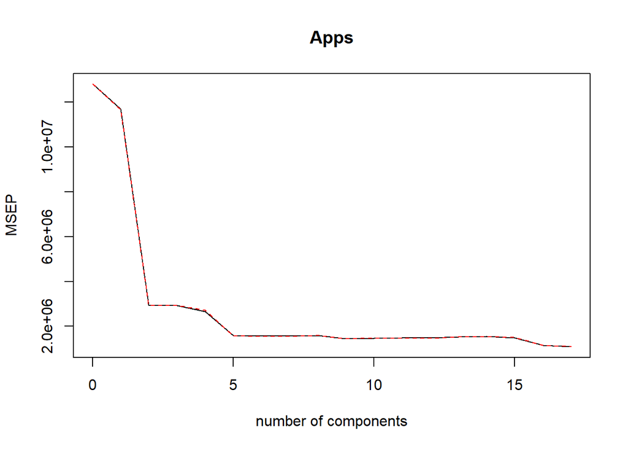

```r
library(pls)
pcr.fit = pcr(Apps~., data=College.train, scale=T, validation="CV")
validationplot(pcr.fit, val.type="MSEP")
```

```r
pcr.pred = predict(pcr.fit, College.test, ncomp=10)
mean((College.test[, "Apps"] - pcr.pred)^2)
```

```
## [1] 2941640
```

```r
# the highest test error so far
```

6. Fit a PLS model on the training set, with M chosen by crossvalidation. Report the test error obtained, along with the value of M selected by cross-validation.

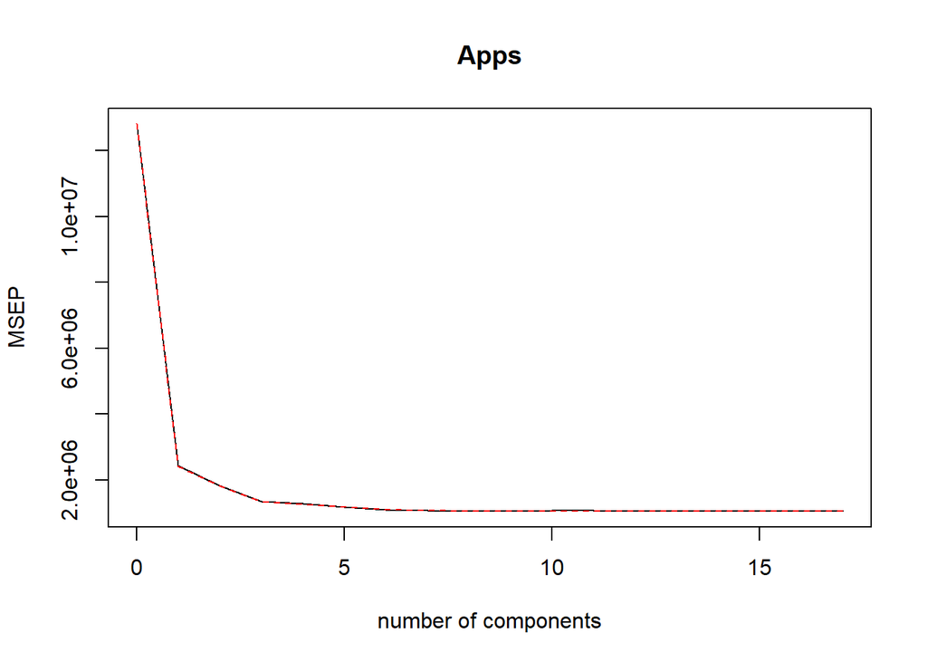

```r
pls.fit = plsr(Apps~., data=College.train, scale=T, validation="CV")
validationplot(pls.fit, val.type="MSEP")
```

```r
pls.pred = predict(pls.fit, College.test, ncomp=10)
mean((College.test[, "Apps"] - pls.pred)^2)
```

```
## [1] 1429985
```

```r
# test error is smaller than OLS
```

7. Comment on the results obtained. How accurately can we predict the number of college applications received? Is there much diﬀerence among the test errors resulting from these ﬁve approaches?

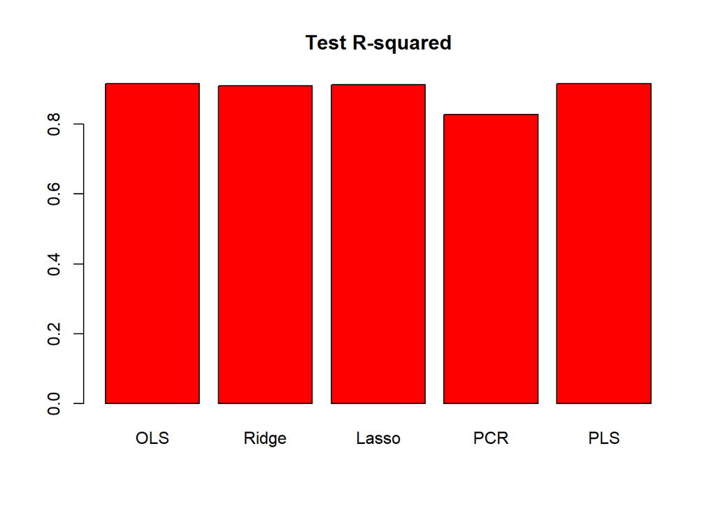

```r
# calculating the test R square to compare models
test.avg = mean(College.test[, "Apps"])
lm.test.r2 = 1 - mean((College.test[, "Apps"] - lm.pred)^2) /mean((College.test[, "Apps"] - test.avg)^2)
ridge.test.r2 = 1 - mean((College.test[, "Apps"] - ridge.pred)^2) /mean((College.test[, "Apps"] - test.avg)^2)
lasso.test.r2 = 1 - mean((College.test[, "Apps"] - lasso.pred)^2) /mean((College.test[, "Apps"] - test.avg)^2)
pcr.test.r2 = 1 - mean((College.test[, "Apps"] - pcr.pred)^2) /mean((College.test[, "Apps"] - test.avg)^2)
pls.test.r2 = 1 - mean((College.test[, "Apps"] - pls.pred)^2) /mean((College.test[, "Apps"] - test.avg)^2)
barplot(c(lm.test.r2, ridge.test.r2, lasso.test.r2, pcr.test.r2, pls.test.r2), col="red", names.arg=c("OLS", "Ridge", "Lasso", "PCR", "PLS"), main="Test R-squared")
```